# Reproducible Research: Peer Assessment 1

## Intro

This assignment makes use of data from a personal activity monitoring device.  
The data consists of two months of data from an anonymous individual collected during the months of October and November, 2012 and include the number of steps taken in 5 minute intervals each day.

## Initialisation

First load the needed libraries / packages and set the working directory

```r
    library(ggplot2) # for plotting
    library(dplyr) # for manipulating data
    library(Hmisc) # for the impute function (had to install this package first in rstudio)
    setwd("~/Documents/Machine Learning/reproducible research/RepData_PeerAssessment1")
```

## Loading and preprocessing the data

```r
    activData <- read.csv('activity.csv')
```

## What is mean total number of steps taken per day?

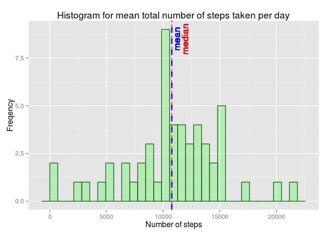

```r
    activeDays <- activData %>% group_by(as.Date(date)) %>% summarise(totalSteps=sum(steps))
    colnames(activeDays) <- c("date", "totalSteps")

    meanSteps <- mean((activeDays$totalSteps), na.rm = TRUE)
    medianSteps <- median((activeDays$totalSteps), na.rm = TRUE)

    #histTotalSteps <-
        ggplot(data=activeDays, aes(x=totalSteps)) +
            geom_histogram(stat="bin",
                        col="dark green",
                        fill="green",
                        alpha = .2) +
            labs(title="Histogram for mean total number of steps taken per day", x="Number of steps", y="Freqency") +
            geom_vline(aes(xintercept=meanSteps), color="blue", linetype="dashed", size=1, vjust=0.5) +
            geom_text(aes(x=meanSteps, label="mean", y=8.5), colour="blue", angle=90, vjust=1.2, text=element_text(size=6)) +
            geom_vline(aes(xintercept=meanSteps), color="red", linetype="dashed", size=0.5) +
            geom_text(aes(x=meanSteps, label="median", y=8.5), colour="red", angle=90, vjust=2.4, text=element_text(size=6))
```

```r
    #print(histTotalSteps)
    cat("Mean total number of steps: ", meanSteps)
```

```
## Mean total number of steps:  10766.19
```

```r
    cat("Median total number of steps: ", medianSteps)
```

```
## Median total number of steps:  10765
```

## What is the average daily activity pattern?

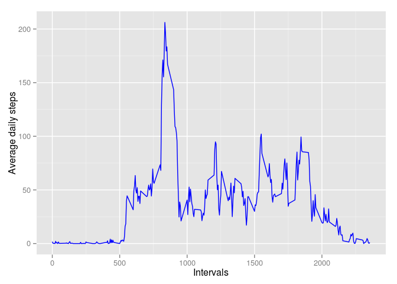

```r
    averageStepsPerTimeBlock <- aggregate(x=list(meanSteps=activData$steps), by=list(interval=activData$interval), FUN=mean, na.rm=TRUE)

    ggplot(data=averageStepsPerTimeBlock, aes(x=interval, y=meanSteps)) +
        geom_line(colour="blue") +
        xlab("Intervals") +
        ylab("Average daily steps")
```

## Imputing missing values

Calculate and report the total number of missing values in the dataset (i.e. the total number of rows with NAs)  
Calculation of the missing values in the set:

```r
    missingCount <- sum(is.na(activData$steps))
    cat("Number of missing values: ", missingCount)
```

```
## Number of missing values:  2304
```

Devise a strategy for filling in all of the missing values in the dataset. The strategy does not need to be sophisticated. For example, you could use the mean/median for that day, or the mean for that 5-minute interval, etc.  
Create a new dataset with the missing values added.  
The impute function is designed for this task: import / add missing data to a set based on a function, I choose the mean function. Impute is from the Hmisc package.

First create a new set, then add the missing values using the mean parameter with the impute function.

```r
    activDataCompleted <- activData
    activDataCompleted$steps <- impute(activData$steps, fun=mean)
```